# Elephants Distribution Modelling

Mary Muthee

5/14/2023

Running Maxent in R requires several packages. Specifically, the “dismo” package, which contains maxent function that calls maxent.jar in R, the raster package, which provides functions for analyzing gridded data, the rgeos package, which provides functions for analyzing spatial data.

```r
#setting up the working environment
wd<-"C:/Users/PC/Desktop/Spatial Data Mining/Project"
setwd(wd)
```

Loading the necessary packages

```r
library(terra)
library(predicts)
library(geodata)
library(sp)
library(sf)
library(dismo)
library(ggplot2)
library(spatstat)
library(dplyr)
library(raster)
library(rasterVis)
library(tidyr)
library(rgdal)
library(rgeos)
library(rJava)
library(patchwork)
```

Loading the dataset

```r
Africa<-st_read("africa_final.shp")
#downloading the elephants occurence
elephants<-geodata::sp_occurrence("Loxodonta","africana**",geo = FALSE)
```

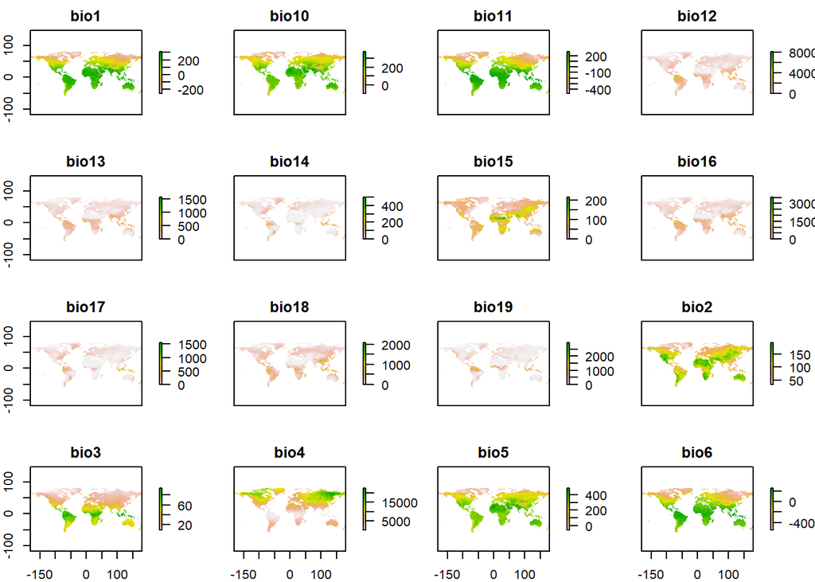

```r
#importing the bioclimatic variables
wbio<-stack(list.files(pattern = "\\.bil$"))
plot(wbio)
```

We transform the Africa boundary coordinate reference system and later on mask the bioclimatic variables to this boundary. The boundary will serve as our study area

```r
#defining the crs
projcrs <- "+proj=longlat +datum=WGS84"

#creating a sf feature
boundary_wgs84<-st_as_sf(x=Africa,
                           coords =c("lon","lat"),
                           crs=projcrs)
#Checking the crs
crs(boundary_wgs84)
```

```
## [1] "GEOGCRS[\"WGS 84\",\n    DATUM[\"World Geodetic System 1984\",\n        ELLIPSOID[\"WGS 84\",6378137,298.257223563,\n            LENGTHUNIT[\"metre\",1]]],\n    PRIMEM[\"Greenwich\",0,\n        ANGLEUNIT[\"degree\",0.0174532925199433]],\n    CS[ellipsoidal,2],\n        AXIS[\"geodetic latitu…
```

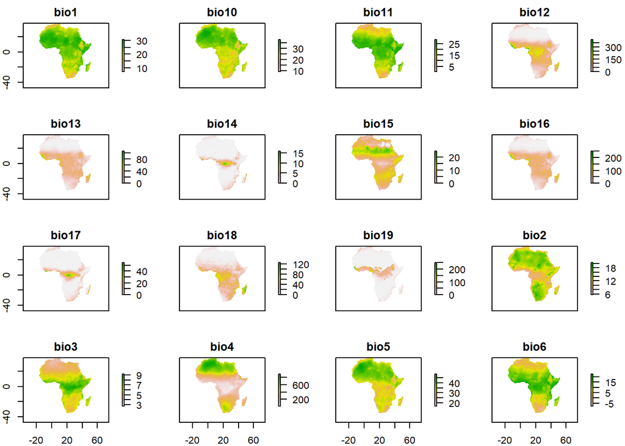

```r
#cropping and masking
Abio_crop <- crop(wbio, boundary_wgs84)
Abio_msk <- mask(Abio_crop, boundary_wgs84)
Abio_msk<-Abio_msk/10

#plotting the masked layer
plot(Abio_msk)
```

Since some of our records do not have appropriate coordinates and some have missing locational data, we need to remove them from our dataset. This particular piece of code also returns the number of records that are removed from the dataset. Additionally, we remove duplicate records and create a subset of the cleaned data with the duplicates removed.

```r
# how many rows and columns?
dim(elephants)
```

```
## [1] 13072   188
```

```r
#removing the rows with no latitude and longitude
elephants_geo<-subset(elephants, !is.na(lon) & !is.na(lat))

# how many rows and columns?
dim(elephants_geo)
```

```
## [1] 11667   188
```

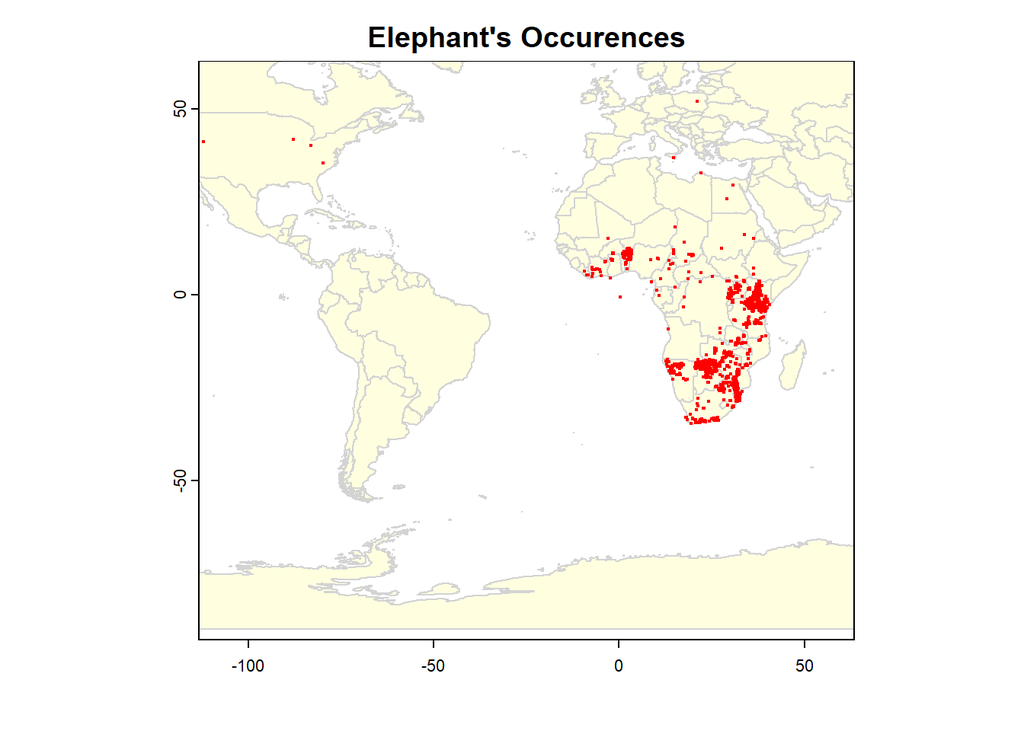

```r
#Plotting the data
wrld <- world(path=".")
plot(wrld, xlim=c(-110,60), ylim=c(-90,60),
     col="light yellow", border="light gray",
     main="Elephant's Occurences")
points(elephants_geo$lon, elephants_geo$lat, col='red',pch=1, cex=0.3)
```

In the figure above, we can see several points that appear outside the known distribution of Lotodona Africana (Africa) and we need to remove these from our occurrence dataset.

```r
#removing occurence data that lies outisde Africa
elephants_geo<-elephants_geo[elephants_geo$continent !="EUROPE" & elephants_geo$continent!="NORTH_AMERICA",]

#Data cleaning
dups<- duplicated(elephants_geo[,c('lon','lat')])

# number of duplicates
sum(dups)
```

```
## [1] 880
```

```r
# keep the records that are _not_ duplicated
elephants_geo <- elephants_geo[!dups, ]

#removing some of the data columns
elephants_geo<-subset(elephants_geo,select=c(lat,lon,occurrenceStatus))

# Find the rows with missing occurrence values
missing_occurrence <- which(is.na(elephants_geo$lon))

# Print the row indices
print(missing_occurrence)
```

```
## [1] 331
```

```r
#remove the row with the missing value
elephants_geo<-
  elephants_geo[!is.na(elephants_geo$lat),]

#checking the elpehants columns classes
lapply(elephants_geo, class)
```

```
## $lat
## [1] "numeric"
##
## $lon
## [1] "numeric"
##
## $occurrenceStatus
## [1] "character"
```

Up to this point we have been working with occurence data as data frame, but it has no spatial relationship with environmental layers. So we need to make the data spatial.

```r
#defining the crs
projcrs <- "+proj=longlat +datum=WGS84"

#converting the occurence data into sf feature
elephants_geo_sf<-st_as_sf(x=elephants_geo,
                           coords=c("lon","lat"),
                           crs=projcrs)

#reprojecting the data
Africa_utm<-st_transform(Africa,32735)
elephants_geo_utm<-st_transform(elephants_geo_sf, 32735)

#checking the crs
crs(Africa_utm)
```

```
## [1] "PROJCRS[\"WGS 84 / UTM zone 35S\",\n    BASEGEOGCRS[\"WGS 84\",\n        DATUM[\"World Geodetic System 1984\",\n            ELLIPSOID[\"WGS 84\",6378137,298.257223563,\n                LENGTHUNIT[\"metre\",1]]],\n        PRIMEM[\"Greenwich\",0,\n            ANGLEUNIT[\"degree\",0.01745329251…
```

```r
crs(elephants_geo_utm)
```

```
## [1] "PROJCRS[\"WGS 84 / UTM zone 35S\",\n    BASEGEOGCRS[\"WGS 84\",\n        DATUM[\"World Geodetic System 1984\",\n            ELLIPSOID[\"WGS 84\",6378137,298.257223563,\n                LENGTHUNIT[\"metre\",1]]],\n        PRIMEM[\"Greenwich\",0,\n            ANGLEUNIT[\"degree\",0.01745329251…
```

We now visualize the occurence data together with our boundary (Africa)

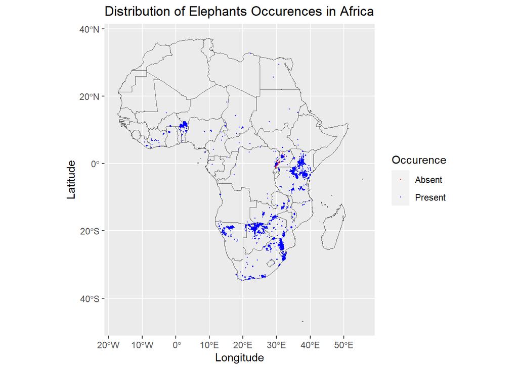

```r
ggplot() +
  geom_sf(data = Africa,
          fill = NA) +
  geom_point(data = elephants_geo,
          aes(x=lon,y=lat,color=occurrenceStatus), size = 0.2) +
  scale_color_manual(name = "Occurence",
                     values = c("red", "blue"),
                     labels = c("Absent", "Present"))+
  labs(title = "Distribution of Elephants Occurences in Africa",
       x="Longitude", y="Latitude")
```

We now use the “elephants_geo_Sf” to extract bioclimatic variables from the “Abio_mask”.

```r
biovalues<-raster::extract(Abio_msk,
                           elephants_geo_sf)%>%
  bind_cols(elephants_geo_sf) %>%
  as.data.frame()
```

In the next step, we selected 5384 random background points from the study area. To make our experiment reproducible (i.e., select the same set of points), we used a static seed via set.seed(1) function. Then, we plotted the background points together with the study area and occurrence data.

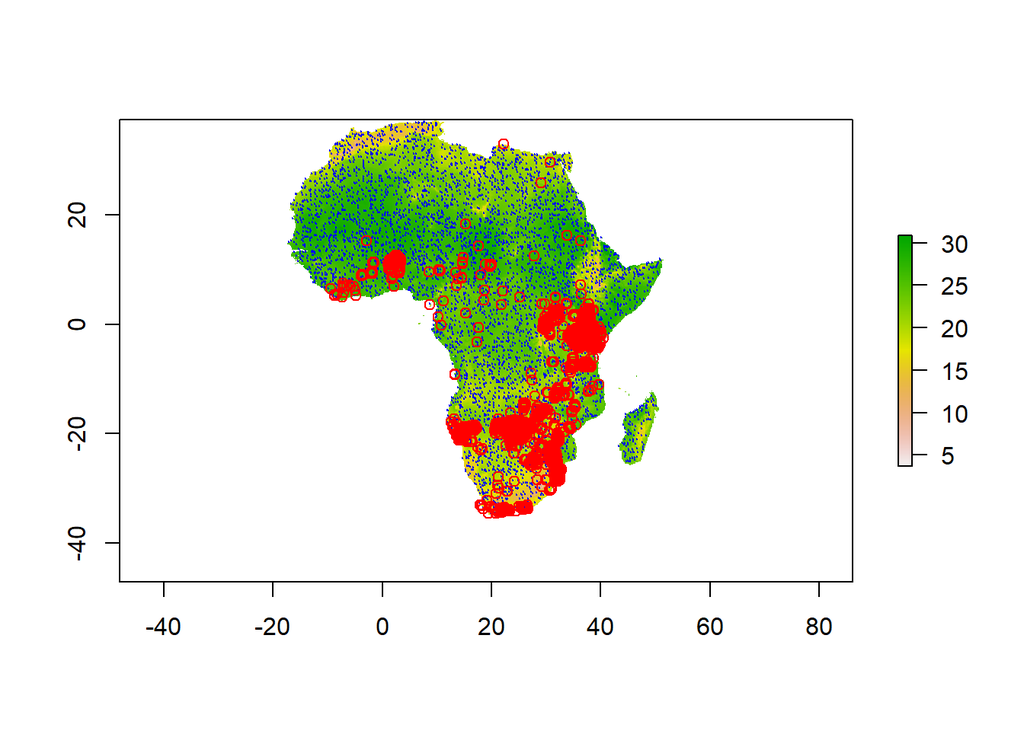

```r
#select random points from our study area
set.seed(1)
bg<-sampleRandom(x=Abio_msk,
                 size = 5384,
                 na.rm=TRUE,
                 sp=TRUE)

#plotting the study area,occurences and bg
plot(Abio_msk[[1]])
plot(bg,add=TRUE,col="blue",cex=0.1,pch=21)
plot(elephants_geo_sf,add=TRUE, col="red")
```

Split occurrence data into training & testing We randomly selected 50% of the occurrence data for model training and used the remaining for model testing. To make our experiment reproducible (i.e., select the same set of points), we used a static seed via set.seed(1) function.

```r
set.seed(1)

#randomly select 50% for training
selected<-sample(1:nrow(biovalues),
                 nrow(biovalues) *0.5)

#get the training and testing sets
occ_train<-biovalues[selected,]
occ_test<-biovalues[-selected,]
occ_train<-subset(occ_train,
                  select=-c(occurrenceStatus))
occ_train_final<-na.omit(occ_train)
occ_test<-subset(occ_test,
                 select=-c(occurrenceStatus))
occ_test_final<-na.omit(occ_test)
occ_test_final<-subset(occ_test_final,
                       select=-c(geometry))

#converting bg_values to sf object
bg_values<-st_as_sf(bg,
                    coords = c("x","y"))
# set the coordinate reference system (CRS)
st_crs(bg_values) <- "+proj=longlat +datum=WGS84"
```

```r
# repeat the number 1 as many numbers as the number of rows
# in p, and repeat 0 as the rows of background points
pa <- c(rep(1, nrow(occ_train_final)),
        rep(0, nrow(bg_values)))

#creating a data frame
padf<-as.data.frame(rbind(occ_train_final,bg_values))

#removing the geometry column since maxent does not require it
padf<-subset(padf, select=-c(geometry))

#checking if there are Na values
which(is.na(padf))
```

```
## integer(0)
```

Setting up the Maxent path.In order for Maxent to work properly in R, the maxent.jar file needs to be accessible by dismo package.

```r
if (!file.exists(paste0(system.file("java",
                                    package = "dismo"),"/maxent.jar"))){
  utils::download.file(url = "https://raw.githubusercontent.com/mrmaxent/Maxent/master/ArchivedReleases/3.3.3k/maxent.jar",
                       destfile = paste0(system.file("java", package = "dismo"),
                                         "/maxent.jar"), mode = "wb")

}
```

We now implement the model.

```r
#generating the model
mod<-maxent(x=padf,
            p=pa,
           args=c("responsecurves"),
            species="Elephants")
mod
```

```
## class    : MaxEnt
## variables: bio1 bio10 bio11 bio12 bio13 bio14 bio15 bio16 bio17 bio18 bio19 bio2 bio3 bio4 bio5 bio6 bio7 bio8 bio9
```

```r
mod@results
```

```
##                                                                                          [,1]
## X.Training.samples                                                                  5356.0000
## Regularized.training.gain                                                              0.4580
## Unregularized.training.gain                                                            0.5133
## Iterations                                                                           500.0000
## Training.AUC                                                                           0.7459
## X.Background.points                                                                10495.0000
## bio1.contribution                                                                      0.3560
## bio10.contribution                                                                     1.1950
## bio11.contribution                                                                     0.0390
## bio12.contribution                                                                    24.8545
## bio13.contribution                                                                     0.1057
## bio14.contribution                                                                     0.9993
## bio15.contribution                                                                     5.5317
## bio16.contribution                                                                     5.6551
## bio17.contribution                                                                     0.8099
## bio18.contribution                                                                    40.7934
## bio19.contribution                                                                     0.6559
## bio2.contribution                                                                      0.3109
## bio3.contribution                                                                      0.7372
## bio4.contribution                                                                     10.2287
## bio5.contribution                                                                      0.2404
## bio6.contribution                                                                      2.3353
## bio7.contribution                                                                      0.2701
## bio8.contribution                                                                      3.8906
## bio9.contribution                                                                      0.9912
## bio1.permutation.importance                                                            1.2316
## bio10.permutation.importance                                                           4.6311
## bio11.permutation.importance                                                           0.2064
## bio12.permutation.importance                                                          17.6785
## bio13.permutation.importance                                                           0.5770
## bio14.permutation.importance                                                           4.8818
## bio15.permutation.importance                                                           6.8875
## bio16.permutation.importance                                                           4.6083
## bio17.permutation.importance                                                           1.5330
## bio18.permutation.importance                                                          28.1665
## bio19.permutation.importance                                                           2.3988
## bio2.permutation.importance                                                            0.7030
## bio3.permutation.importance                                                            2.7169
## bio4.permutation.importance                                                            8.3969
```

[output cut: 28 more lines]

```
## Equal.training.sensitivity.and.specificity.logistic.threshold                          0.5192
## Equal.training.sensitivity.and.specificity.area                                        0.3330
## Equal.training.sensitivity.and.specificity.training.omission                           0.3325
## Maximum.training.sensitivity.plus.specificity.cumulative.threshold                     9.6391
## Maximum.training.sensitivity.plus.specificity.logistic.threshold                       0.3828
## Maximum.training.sensitivity.plus.specificity.area                                     0.5090
## Maximum.training.sensitivity.plus.specificity.training.omission                        0.0566
## Balance.training.omission..predicted.area.and.threshold.value.cumulative.threshold     1.6199
## Balance.training.omission..predicted.area.and.threshold.value.logistic.threshold       0.1162
## Balance.training.omission..predicted.area.and.threshold.value.area                     0.6484
## Balance.training.omission..predicted.area.and.threshold.value.training.omission        0.0078
## Equate.entropy.of.thresholded.and.original.distributions.cumulative.threshold          1.9813
## Equate.entropy.of.thresholded.and.original.distributions.logistic.threshold            0.1417
## Equate.entropy.of.thresholded.and.original.distributions.area                          0.6332
## Equate.entropy.of.thresholded.and.original.distributions.training.omission             0.0101
```

We can now make projections using predict function

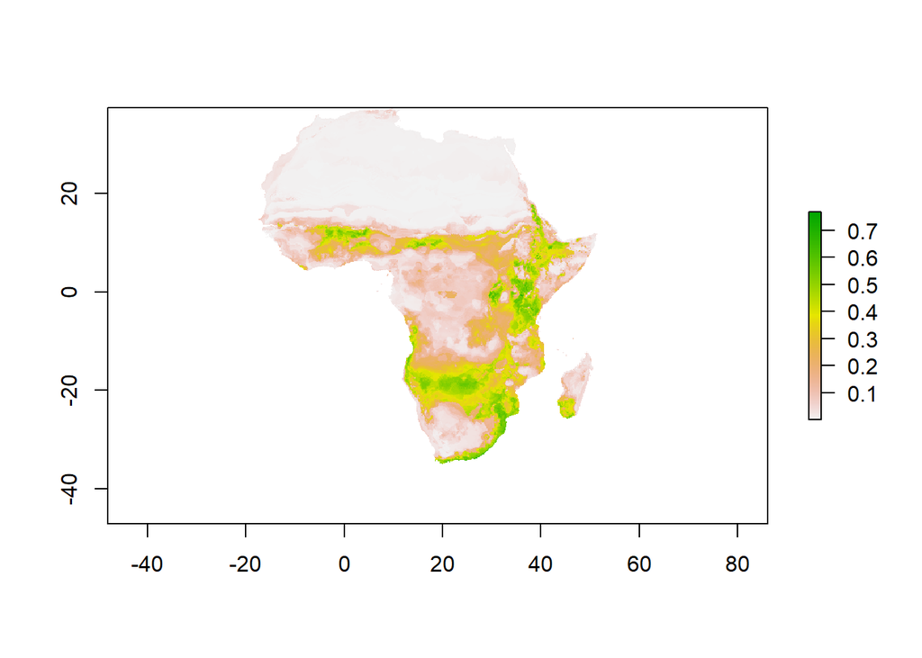

```r
#performing predictions
pred1<-predict(mod,Abio_msk)
plot(pred1)
```

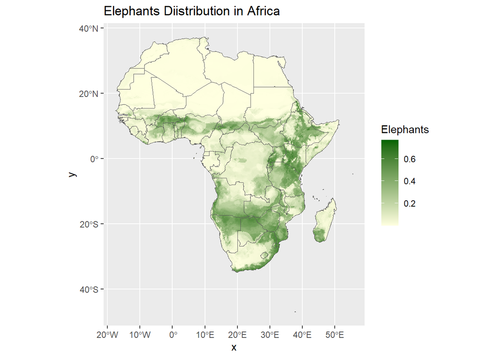

```r
#converting the prediction to dataframe
df<-as.data.frame(pred1,xy=TRUE)

#visualizing it
ggplot(data = df)+
  geom_raster(aes(x=x,y=y,fill=layer))+
  scale_fill_gradient(name = "Elephants",
                      low = "lightyellow",
                      high = "darkgreen",
                      na.value = NA) +
  geom_sf(data = boundary_wgs84,
          fill = NA)+
  labs(title="Elephants Diistribution in Africa")
```

Model Evaluation.

```r
#evaluating the model using training set
mod_eval_train <- dismo::evaluate(p = occ_train_final, a = bg_values, model = mod)
print(mod_eval_train)
```

```
## class          : ModelEvaluation
## n presences    : 5356
## n absences     : 5384
## AUC            : 0.971952
## cor            : 0.8510341
## max TPR+TNR at : 0.3819985
```

```r
#evaluating the model using testing set
mod_eval_test <- dismo::evaluate(p = occ_test_final,a = bg_values,model = mod)
print(mod_eval_test)
```

```
## class          : ModelEvaluation
## n presences    : 5364
## n absences     : 5384
## AUC            : 0.9719414
## cor            : 0.8512446
## max TPR+TNR at : 0.3782863
```

We can perform predictions in relation to the projected climate data.

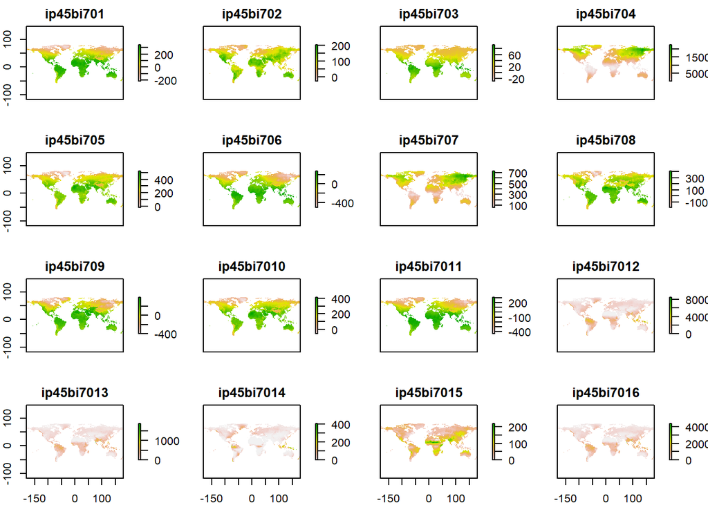

```r
#importing the dataset
b1<-raster("ip45bi701.tif")
b2<-raster("ip45bi702.tif")
b3<-raster("ip45bi703.tif")
b4<-raster("ip45bi704.tif")
b5<-raster("ip45bi705.tif")
b6<-raster("ip45bi706.tif")
b7<-raster("ip45bi707.tif")
b8<-raster("ip45bi708.tif")
b9<-raster("ip45bi709.tif")
b10<-raster("ip45bi7010.tif")
b11<-raster("ip45bi7011.tif")
b12<-raster("ip45bi7012.tif")
b13<-raster("ip45bi7013.tif")
b14<-raster("ip45bi7014.tif")
b15<-raster("ip45bi7015.tif")
b16<-raster("ip45bi7016.tif")
b17<-raster("ip45bi7017.tif")
b18<-raster("ip45bi7018.tif")
b19<-raster("ip45bi7019.tif")

#stacking the raster layers
fwbio<-stack(b1,b2,b3,b4,b5,b6,b7,b8,b9,b10,b11,b12
              ,b13,b14,b15,b16,b17,b18,b19)
plot(fwbio)
```

```r
#renaming the fwbio names
names(fwbio)
```

```
##  [1] "ip45bi701"  "ip45bi702"  "ip45bi703"  "ip45bi704"  "ip45bi705"
##  [6] "ip45bi706"  "ip45bi707"  "ip45bi708"  "ip45bi709"  "ip45bi7010"
## [11] "ip45bi7011" "ip45bi7012" "ip45bi7013" "ip45bi7014" "ip45bi7015"
## [16] "ip45bi7016" "ip45bi7017" "ip45bi7018" "ip45bi7019"
```

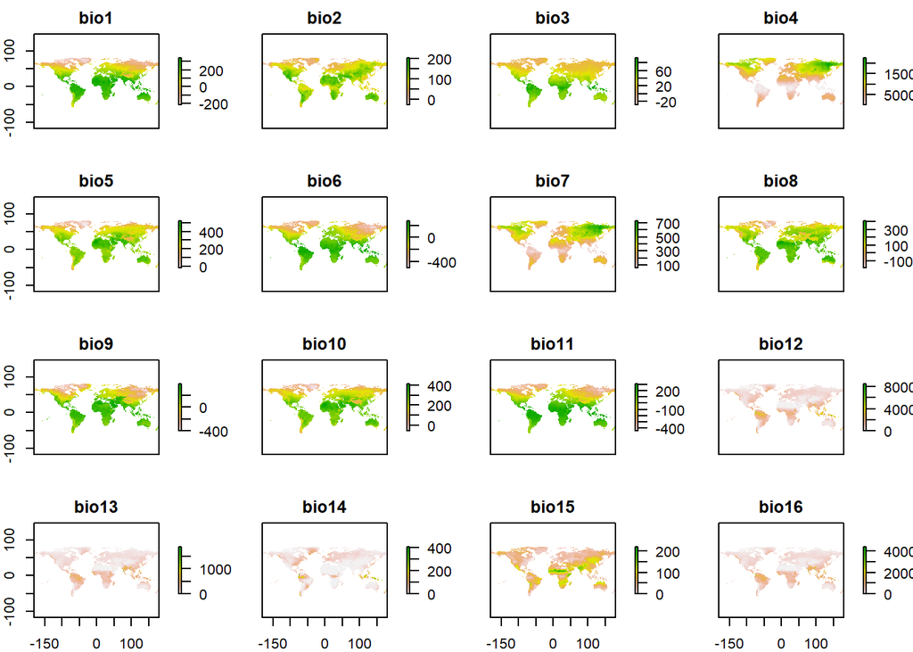

```r
fwbionames <- paste0("bio", 1:19)
names(fwbio)<-fwbionames
plot(fwbio)
```

We mask the projected climate data to our Area of study.

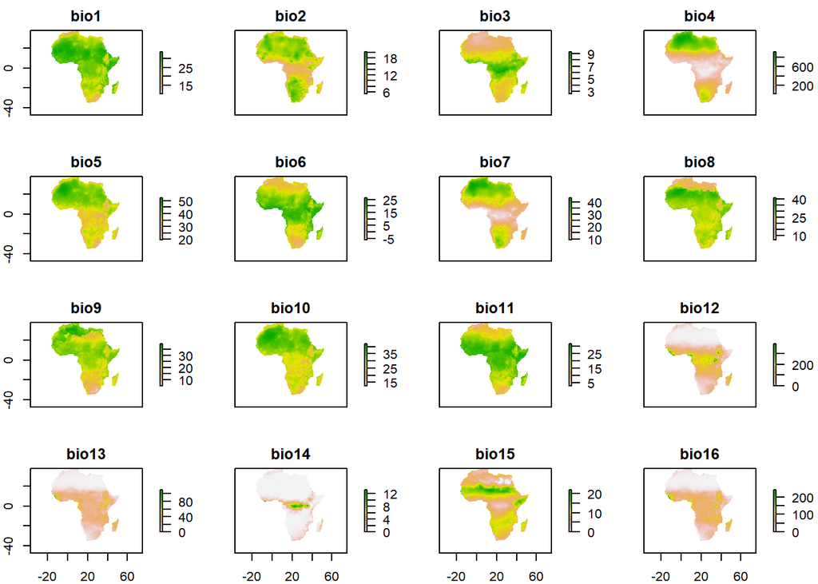

```r
#cropping and masking
fAbio_crop <- crop(fwbio, boundary_wgs84)
fAbio_msk <- mask(fAbio_crop, boundary_wgs84)
fAbio_msk<-fAbio_msk/10
plot(fAbio_msk)
```

We now predict the distribution of elephants in realted to the projected climate data. In 50 years time.

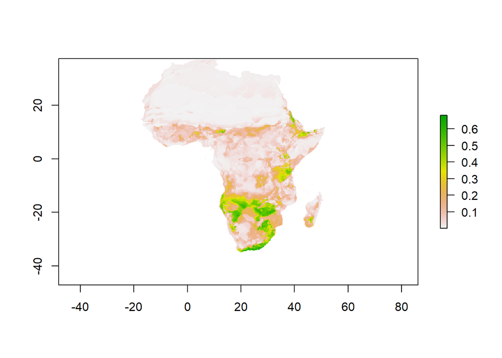

```r
elephants_proj<-predict(mod,fAbio_msk)
plot(elephants_proj)
```

We visulize the predicted distribution.

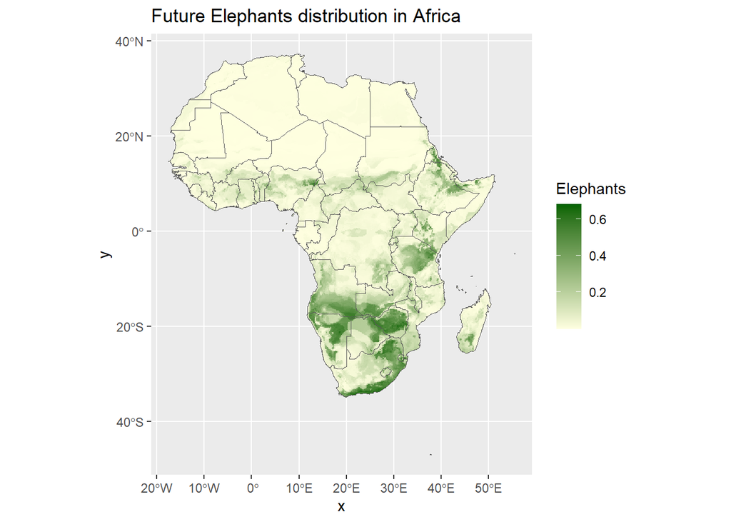

```r
#converting the prediction to dataframe
fdf<-as.data.frame(elephants_proj,xy=TRUE)

#plotting
ggplot(data = fdf)+
  geom_raster(aes(x=x,y=y,fill=layer))+
  scale_fill_gradient(name = "Elephants",
                      low = "lightyellow",
                      high = "darkgreen",
                      na.value = NA) +
  geom_sf(data = boundary_wgs84,
          fill = NA)+
  labs(title="Future Elephants distribution in Africa")
```

We finally create a map plot showing the current and future distribution of elephants

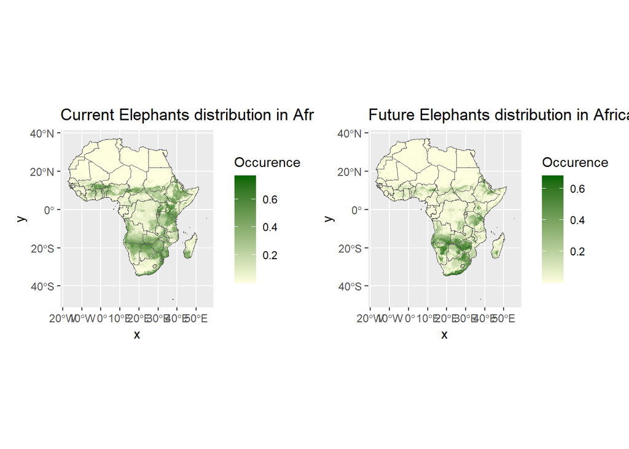

```r
p1<-ggplot(data = df)+
  geom_raster(aes(x=x,y=y,fill=layer))+
  scale_fill_gradient(name = "Occurence",
                      low = "lightyellow",
                      high = "darkgreen",
                      na.value = NA) +
  geom_sf(data = boundary_wgs84,
          fill = NA)+
  ggtitle("Current Elephants distribution in Africa")
p2<-ggplot(data = fdf)+
  geom_raster(aes(x=x,y=y,fill=layer))+
  scale_fill_gradient(name = "Occurence",
                      low = "lightyellow",
                      high = "darkgreen",
                      na.value = NA) +
  geom_sf(data = boundary_wgs84,
          fill = NA)+
  ggtitle("Future Elephants distribution in Africa")

p1+p2+plot_layout(ncol = 2)
```